# Project Python Foundations: FoodHub Data Analysis

### Context

The number of restaurants in New York is increasing day by day. Lots of students and busy professionals rely on those restaurants due to their hectic lifestyles. Online food delivery service is a great option for them. It provides them with good food from their favorite restaurants. A food aggregator company FoodHub offers access to multiple restaurants through a single smartphone app.

The app allows the restaurants to receive a direct online order from a customer. The app assigns a delivery person from the company to pick up the order after it is confirmed by the restaurant. The delivery person then uses the map to reach the restaurant and waits for the food package. Once the food package is handed over to the delivery person, he/she confirms the pick-up in the app and travels to the customer's location to deliver the food. The delivery person confirms the drop-off in the app after delivering the food package to the customer. The customer can rate the order in the app. The food aggregator earns money by collecting a fixed margin of the delivery order from the restaurants.

### Objective

The food aggregator company has stored the data of the different orders made by the registered customers in their online portal. They want to analyze the data to get a fair idea about the demand of different restaurants which will help them in enhancing their customer experience. Suppose you are hired as a Data Scientist in this company and the Data Science team has shared some of the key questions that need to be answered. Perform the data analysis to find answers to these questions that will help the company to improve the business.

### Data Description

The data contains the different data related to a food order. The detailed data dictionary is given below.

### Data Dictionary

- order_id: Unique ID of the order
- customer_id: ID of the customer who ordered the food
- restaurant_name: Name of the restaurant
- cuisine_type: Cuisine ordered by the customer
- cost_of_the_order: Cost of the order
- day_of_the_week: Indicates whether the order is placed on a weekday or weekend (The weekday is from Monday to Friday and the weekend is Saturday and Sunday)
- rating: Rating given by the customer out of 5
- food_preparation_time: Time (in minutes) taken by the restaurant to prepare the food. This is calculated by taking the difference between the timestamps of the restaurant's order confirmation and the delivery person's pick-up confirmation.
- delivery_time: Time (in minutes) taken by the delivery person to deliver the food package. This is calculated by taking the difference between the timestamps of the delivery person's pick-up confirmation and drop-off information

### Let us start by importing the required libraries

```python
# Installing the libraries with the specified version.
%pip install numpy
%pip install pandas
%pip install matplotlib
%pip install seaborn
```

[output not shown]

**Note**: *After running the above cell, kindly restart the notebook kernel and run all cells sequentially from the start again.*

```python
# import libraries for data manipulation
import numpy as np
import pandas as pd

# import libraries for data visualization
import matplotlib.pyplot as plt
import seaborn as sns
```

### Understanding the structure of the data

```python
df = pd.read_csv("foodhub_order.csv")

#To be safe so I can protect the original data I will create a copy
food_hub_data = df.copy()
```

```python
food_hub_data.head()
```

|  | order_id | customer_id | restaurant_name | cuisine_type | cost_of_the_order | day_of_the_week | rating | food_preparation_time | delivery_time |
| --- | --- | --- | --- | --- | --- | --- | --- | --- | --- |
| 0 | 1477147 | 337525 | Hangawi | Korean | 30.75 | Weekend | Not given | 25 | 20 |
| 1 | 1477685 | 358141 | Blue Ribbon Sushi Izakaya | Japanese | 12.08 | Weekend | Not given | 25 | 23 |
| 2 | 1477070 | 66393 | Cafe Habana | Mexican | 12.23 | Weekday | 5 | 23 | 28 |
| 3 | 1477334 | 106968 | Blue Ribbon Fried Chicken | American | 29.20 | Weekend | 3 | 25 | 15 |
| 4 | 1478249 | 76942 | Dirty Bird to Go | American | 11.59 | Weekday | 4 | 25 | 24 |

### **Question 1:** How many rows and columns are present in the data? [0.5 mark]

```python
food_hub_data.shape
```

```
(1898, 9)
```

#### Observations:

- There are 1898 rows and 9 columns within the data set
- Each row represents a specific order with a primary identifier of order_id

### **Question 2:** What are the datatypes of the different columns in the dataset? (The info() function can be used) [0.5 mark]

```python
# Write your code here
food_hub_data.info()
```

```
<class 'pandas.core.frame.DataFrame'>
RangeIndex: 1898 entries, 0 to 1897
Data columns (total 9 columns):
 #   Column                 Non-Null Count  Dtype
---  ------                 --------------  -----
 0   order_id               1898 non-null   int64
 1   customer_id            1898 non-null   int64
 2   restaurant_name        1898 non-null   object
 3   cuisine_type           1898 non-null   object
 4   cost_of_the_order      1898 non-null   float64
 5   day_of_the_week        1898 non-null   object
 6   rating                 1898 non-null   object
 7   food_preparation_time  1898 non-null   int64
 8   delivery_time          1898 non-null   int64
dtypes: float64(1), int64(4), object(4)
memory usage: 133.6+ KB
```

#### Observations:

- The following data items may need to be modifed as follows:
  - restaurant_name, cuisine_type, day_of_the_week, and rating are all being classified as an Object(string) type.
    - If possible, it may make better sense to see if day_of_the_week could be represented as a date time object. This would give us the abiity to track trends based on days of the week vs it just being a categorical value.
    - Rating is not always given in the data set, and should be classified as either a float or intenger number. We definitely need to identify data treatment on the missing values.
  - order_id,customer_id, food_prepartion_time, and delivery_time are all correctly classified as integers
  - cost_of_the_order is correctly identified as a floating point value.

### **Question 3:** Are there any missing values in the data? If yes, treat them using an appropriate method. [1 mark]

```python
# Write your code here
print("Null Items Count:", food_hub_data.isnull().sum().sum())
print("Na Items Count:", food_hub_data.isna().sum().sum())
print("Missing Ratings Count:", len(food_hub_data.loc[food_hub_data["rating"] == "Not given"]))

#Since impudation for the rating is risky, and we know that in general not leaving a rating is a valid input, it is best
#to create a subset of the data where the "Not given" values are dropped. The subset of data can be used for any sort
#of evaluation where rating needs to be considered. Keep in mind that since there are 736 rows where the rating is not
#provided we are essentially dropping ~40% of the data.
food_hub_data_rated_only = food_hub_data.loc[food_hub_data["rating"] != "Not given"]
food_hub_data_rated_only.reset_index(drop=True, inplace=True)
food_hub_data_rated_only["rating"] = food_hub_data_rated_only["rating"].astype(int)

print("Missing Ratings Count After Not Given Droped:", len(food_hub_data_rated_only.loc[food_hub_data_rated_only["rating"] == "Not given"]))

food_hub_data_rated_only.head()


#Notes:

#When evaluating
#All columns except rating are input. Predictions are based on the outputs. So rating in this case is the output, which is the most important
#Variable to look at with multi-variate analysis. multi-Variate analysis should be based on comparing all the inputs against
#the output.


#Whenever we are doing the analysis specifically related to rating we have to drop the "Not give" values.
#Whenever you are looking at all data not related to the ratings, then we can use the full data set.

#Bivariate analysis should be based on comparing inputs to output.

#We determine the output based on what it is that we are trying to predict.
```

```
Null Items Count: 0
Na Items Count: 0
Missing Ratings Count: 736
Missing Ratings Count After Not Given Droped: 0
```

|  | order_id | customer_id | restaurant_name | cuisine_type | cost_of_the_order | day_of_the_week | rating | food_preparation_time | delivery_time |
| --- | --- | --- | --- | --- | --- | --- | --- | --- | --- |
| 0 | 1477070 | 66393 | Cafe Habana | Mexican | 12.23 | Weekday | 5 | 23 | 28 |
| 1 | 1477334 | 106968 | Blue Ribbon Fried Chicken | American | 29.20 | Weekend | 3 | 25 | 15 |
| 2 | 1478249 | 76942 | Dirty Bird to Go | American | 11.59 | Weekday | 4 | 25 | 24 |
| 3 | 1477224 | 147468 | Tamarind TriBeCa | Indian | 25.22 | Weekday | 3 | 20 | 24 |
| 4 | 1477859 | 89574 | Barbounia | Mediterranean | 5.97 | Weekday | 3 | 33 | 30 |

#### Observations:

- While all the rows have values for their corresponding columns, there are still instances with the rating column where no rating is given. So we may need to consider treating these specific rows as stated previously.
- As a callout, I split the data into 2 categories:
  - The first category is a subset of the data where all of the rows where the rating = "Not given" has been removed from the data set. This will be useful so that we can perform numeric operations on this dataset without throwing type exception errors. Furthermore, since customer ratings can't safely be impudated, we can use the subset for any data analysis that involves rating without skweing the data for ratings by utilzing the means of ratings grouped by restaurant name or cuisine type. I also type cast the rating values as an int.
  - The second category contains the full original unfilterd data set. Since all of the columns provided in the data set don't contain any missing values we can use the full data set when performing any sort of analysis that doesn't involve rating.

### **Question 4:** Check the statistical summary of the data. What is the minimum, average, and maximum time it takes for food to be prepared once an order is placed? [2 marks]

```python
#Describe data for full data set(rating will not be included)
print("Full Dataset")
food_hub_data.describe()
```

```
Full Dataset
```

|  | order_id | customer_id | cost_of_the_order | food_preparation_time | delivery_time |
| --- | --- | --- | --- | --- | --- |
| count | 1.898000e+03 | 1898.000000 | 1898.000000 | 1898.000000 | 1898.000000 |
| mean | 1.477496e+06 | 171168.478398 | 16.498851 | 27.371970 | 24.161749 |
| std | 5.480497e+02 | 113698.139743 | 7.483812 | 4.632481 | 4.972637 |
| min | 1.476547e+06 | 1311.000000 | 4.470000 | 20.000000 | 15.000000 |
| 25% | 1.477021e+06 | 77787.750000 | 12.080000 | 23.000000 | 20.000000 |
| 50% | 1.477496e+06 | 128600.000000 | 14.140000 | 27.000000 | 25.000000 |
| 75% | 1.477970e+06 | 270525.000000 | 22.297500 | 31.000000 | 28.000000 |
| max | 1.478444e+06 | 405334.000000 | 35.410000 | 35.000000 | 33.000000 |

```python
#Describe data for ratings only data set(rating will be included)
print("Rated orders only Dataset")
food_hub_data_rated_only.describe()
```

```
Rated orders only Dataset
```

|  | order_id | customer_id | cost_of_the_order | rating | food_preparation_time | delivery_time |
| --- | --- | --- | --- | --- | --- | --- |
| count | 1.162000e+03 | 1162.000000 | 1162.000000 | 1162.000000 | 1162.000000 | 1162.000000 |
| mean | 1.477520e+06 | 171939.471601 | 16.760766 | 4.344234 | 27.381239 | 24.154045 |
| std | 5.468713e+02 | 114551.215031 | 7.572578 | 0.741478 | 4.677922 | 4.930999 |
| min | 1.476547e+06 | 5139.000000 | 4.470000 | 3.000000 | 20.000000 | 15.000000 |
| 25% | 1.477062e+06 | 77540.000000 | 12.130000 | 4.000000 | 23.000000 | 20.000000 |
| 50% | 1.477524e+06 | 128655.500000 | 14.600000 | 5.000000 | 27.000000 | 25.000000 |
| 75% | 1.477992e+06 | 276066.250000 | 22.750000 | 5.000000 | 32.000000 | 28.000000 |
| max | 1.478444e+06 | 403019.000000 | 35.410000 | 5.000000 | 35.000000 | 33.000000 |

#### Observations:

- The statistical information for the order_id and customer_id as is, may not be useful in helping us to determine trends about what the demand is for a given restaurant. It would perhaps be more beneficial to group the data by resturant and the day of the week to see which ones have the largest number of orders to give us a better idea of what restaurants are really popular indicating demand.
- The minimum food prep time across all restaurants is 20 minutes.
- The average food prep time across all restaurants is ~27 minutes.
- The max food prep time acorss all restaurants is ~35 minutes

### **Question 5:** How many orders are not rated? [1 mark]

```python
print("Number of orders not rated:", len(food_hub_data.loc[df["rating"] == "Not given"]))
```

```
Number of orders not rated: 736
```

#### Observations:

- The number of orders that are not rated is 736.

### Exploratory Data Analysis (EDA)

### **Question 6:** Explore all the variables and provide observations on their distributions. (Generally, histograms, boxplots, countplots, etc. are used for univariate exploration.) [9 marks]

**Observations on order_id**

```
Number of unique order ids: 1898
```

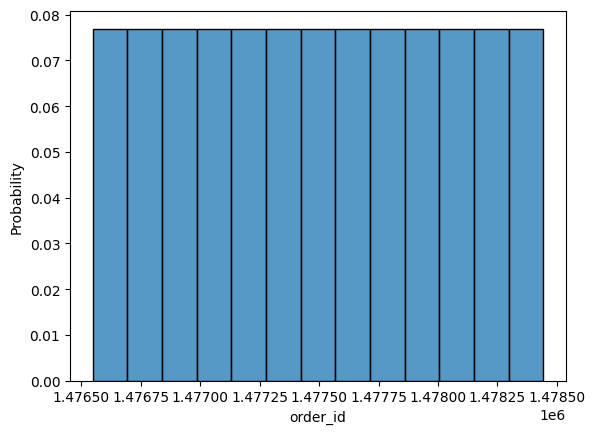

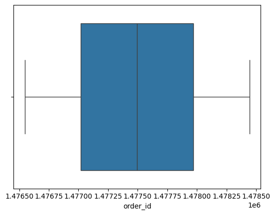

```python
#Calculate the number of unique order ids, as I want to confirm that each order is unique
print("Number of unique order ids:", len(food_hub_data["order_id"].unique()))


sns.histplot(data=food_hub_data, x="order_id", stat="probability")
plt.show()

sns.boxplot(data=food_hub_data,x='order_id')
plt.show()
```

- Based on my hunch, I confirmed that each order id is unique since we have 1898 unique values, which matches the total number of rows in the data set.
- Since each and every value is unqiue we can see that each point gets an equal proability of occurring.
- There isn't any trend to read into here since the order id is a unique identifier assigned by the system for every order that is placed.
- There are no outliers within the order id

**Observations on customer_id**

```
Number of unique customer ids: 1200
```

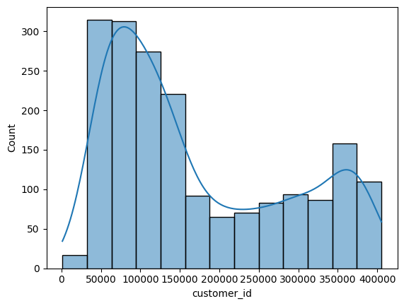

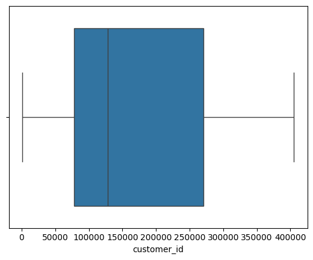

```python
#Calculate the number of unique customer ids
print("Number of unique customer ids:", len(food_hub_data["customer_id"].unique()))

sns.histplot(data=food_hub_data, x="customer_id", kde = True)
plt.show()

sns.boxplot(data=food_hub_data, x="customer_id")
plt.show()
```

**Observations on restaurant_name**

```
Number of unique restaurant names: 178
```

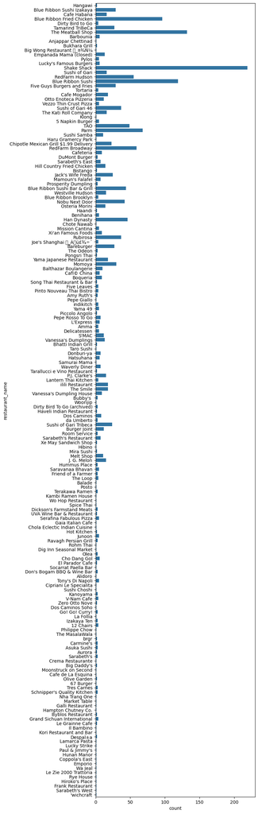

```
Top 15 restaurants
restaurant_name
Shake Shack                      219
The Meatball Shop                132
Blue Ribbon Sushi                119
Blue Ribbon Fried Chicken         96
Parm                              68
RedFarm Broadway                  59
RedFarm Hudson                    55
TAO                               49
Han Dynasty                       46
Blue Ribbon Sushi Bar & Grill     44
Nobu Next Door                    42
Sushi of Gari 46                  37
Rubirosa                          37
Momoya                            30
Five Guys Burgers and Fries       29
Name: count, dtype: int64
```

```python
#Calculate the number of unique restaurant names
print("Number of unique restaurant names:", len(food_hub_data["restaurant_name"].unique()))

plt.figure(figsize=(6.4, 32))
sns.countplot(data=food_hub_data, y="restaurant_name")
plt.show()

#Print the top 15 restaurants
print("Top 15 restaurants")
print(food_hub_data["restaurant_name"].value_counts().sort_values(ascending = False).head(15))
```

- As a hunch, I wanted to confirm the total number of unique restaurant names to have some sort of way of adjusting the graph size since the list was large at 178.
- Since these are restaurant names (categorical data), it made better sense to use a countplot instead of a histogram.
- While the data doesn't show a trend per se, the restaurants that immediately stood out to me as being popoular restaturants that have the highest number of orders are:
  - Shake Shake with ~200 orders
  - The Meatball Shop with ~130 orders
  - Blue Ribbon Sushi with ~120 orders
  - Blue Ribbon Fried Chicken with ~98 orders
- Many restaurants have ~25 or less orders

**Observations on cuisine_type**

```
Number of unique cuisine types: 14
```

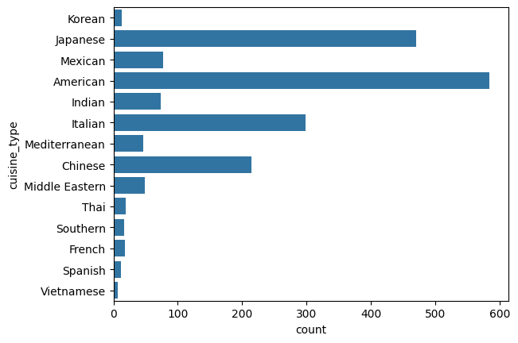

```python
#Calculate the number of unique cuisine types
print("Number of unique cuisine types:", len(food_hub_data["cuisine_type"].unique()))

sns.countplot(data=food_hub_data, y="cuisine_type")
plt.show()
```

**Observations on cost_of_the_order**

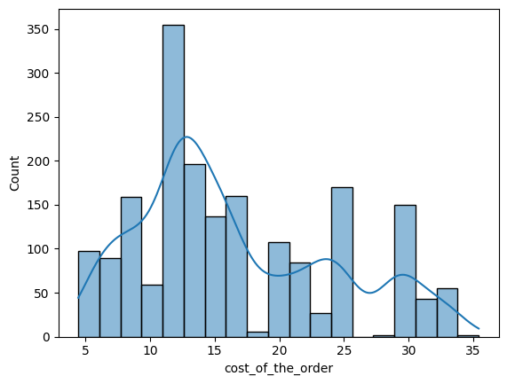

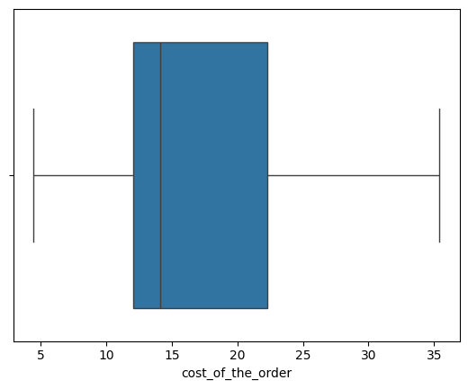

```python
sns.histplot(data=food_hub_data, x="cost_of_the_order", kde = True)
plt.show()

sns.boxplot(data=food_hub_data, x="cost_of_the_order")
plt.show()
```

- There are no ouliers on the cost of the food order
- 75% of the cost ~22 dollars or less
- The data is right skewed
- In general there are less orders made as the cost of the order increases. So this may indicate that price plays a role on determing how frequently orders are made.
- It looks like there is a peak of high orders in the 11-12 dollar price point.

**Observations on day_of_the_week**

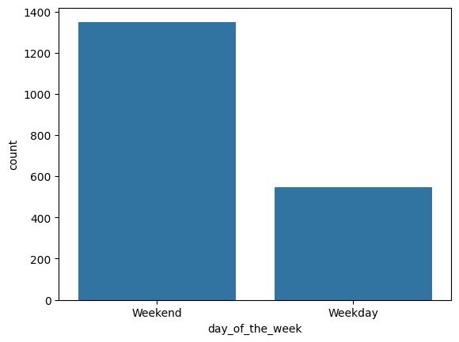

```python
sns.countplot(data=food_hub_data, x="day_of_the_week")
plt.show()
```

- Since the day of the week that the order is placed is categorical it made most sense to use a count plot.
- The majority of orders are placed on the weekends(S-Su) with over 1300 orders placed on the weekend.
- The least amount of orders placed are on the weekdays(M-F) with over 500 orders.
- This lends itself to indicate that food order demands are highest during the weekends.

**Observations on rating**

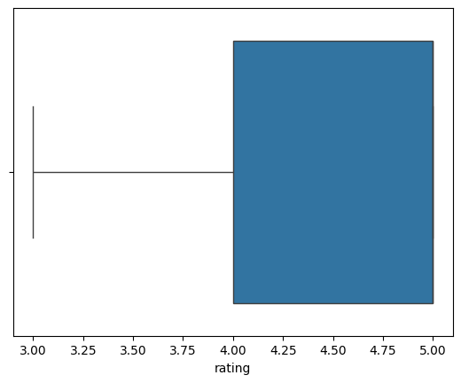

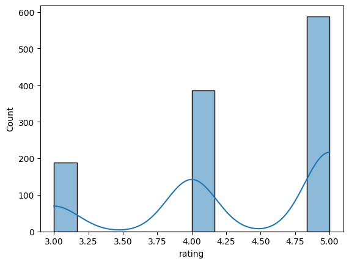

```python
sns.boxplot(data=food_hub_data_rated_only, x="rating")
plt.show()

sns.histplot(data=food_hub_data_rated_only, x="rating", kde = True)
plt.show()
```

- As indicated earlier there are 736 orders placed where a rating was not inidicated. We treated them by removing those rows and evaluating the subset of data where all the ratings are provided.
- ~200 orders placed have a rating of 3
- ~400 orders placed have a rating of 4
- ~600 orders placed have a rating of 5
- ~1000 of rated orders have a rating of 4 or higher. This means that of the rated data set the majority of the orders have a rating of 4 or higher.
- ~1200 of rated orders have a rating of 3 or higher
- As the ratings increases, do does the number of resturants. So there are 3 times as many resturants with rating of 5 compared to resturants with a rating of 3 as an example.

**Observations on food_prepartion_time**

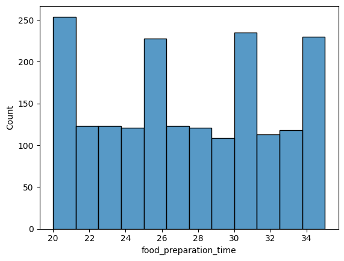

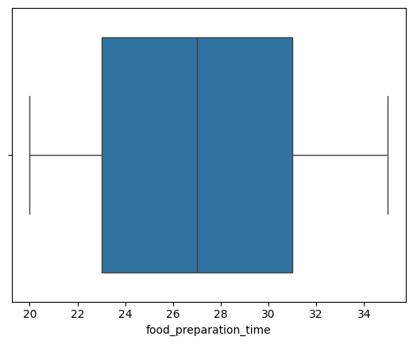

```python
sns.histplot(data=food_hub_data, x="food_preparation_time")
plt.show()

sns.boxplot(data=food_hub_data, x="food_preparation_time")
plt.show()
```

- 75% of the food orders are prepared in 31 minutes or less
- There are no outliers in the food preparation time
- In general I don't notice a trend where I can infer anything about the food prep time to the frequency of orders at least not with univariate analysis.
- There really isn't a skew in the data for the food preparation time.

**Observations on delivery_time**

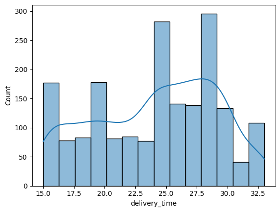

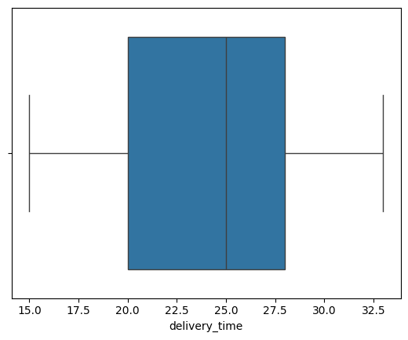

```python
sns.histplot(data=food_hub_data, x="delivery_time", kde = True)
plt.show()

sns.boxplot(data=food_hub_data, x="delivery_time")
plt.show()
```

### **Question 7**: Which are the top 5 restaurants in terms of the number of orders received? [1 mark]

```python
condition = food_hub_data["restaurant_name"].value_counts().sort_values(ascending = False)
condition.head(5)
```

```
restaurant_name
Shake Shack                  219
The Meatball Shop            132
Blue Ribbon Sushi            119
Blue Ribbon Fried Chicken     96
Parm                          68
Name: count, dtype: int64
```

#### Observations:

- Shake shack is the most popular restaurant out of the top 5 with 219 orders received.
- Parm is the least popular restaurant out of the top 5 with 68 orders.
- Thesse observations line up with my initial univariate analysis for restaurant_name and count mentioned earlier.

### **Question 8**: Which is the most popular cuisine on weekends? [1 mark]

```python
filterCondition = food_hub_data["day_of_the_week"] == "Weekend"
result = food_hub_data[filterCondition]["cuisine_type"].value_counts()
maxOrders = result.max()

print(result)
print("The Most Popular Cuisine on the weekend is", result.index.tolist()[0], "with", maxOrders, "orders.")
```

```
cuisine_type
American          415
Japanese          335
Italian           207
Chinese           163
Mexican            53
Indian             49
Mediterranean      32
Middle Eastern     32
Thai               15
French             13
Korean             11
Southern           11
Spanish            11
Vietnamese          4
Name: count, dtype: int64
The Most Popular Cuisine on the weekend is American with 415 orders.
```

#### Observations:

- The Most Popular Cuisine on the weekend is American with 415 orders.

### **Question 9**: What percentage of the orders cost more than 20 dollars? [2 marks]

```python
filterCondition = food_hub_data["cost_of_the_order"] >20
numberOfOrdersOverTwentyDollars = food_hub_data[filterCondition]["cost_of_the_order"].value_counts().count()
totalNumberOfOrders = food_hub_data.shape[0]
percentageOfOrdersOverTwentyDollars = (numberOfOrdersOverTwentyDollars/totalNumberOfOrders)*100

print("The number of orders over twenty dollars:", numberOfOrdersOverTwentyDollars)
print("The total number of orders is", totalNumberOfOrders)
print("The percentage of orders over twenty dollars is", percentageOfOrdersOverTwentyDollars, "%")
```

[output not shown]

### **Question 10**: What is the mean order delivery time? [1 mark]

```python
meanOrderDeliveryTime = food_hub_data["delivery_time"].mean()
print("The mean order delivery time is", meanOrderDeliveryTime, "minutes.")
```

```
The mean order delivery time is 24.161749209694417 minutes.
```

### **Question 11:** The company has decided to give 20% discount vouchers to the top 3 most frequent customers. Find the IDs of these customers and the number of orders they placed. [1 mark]

```python
topThreeCustomers = food_hub_data["customer_id"].value_counts().sort_values(ascending = False).head(3)
print(topThreeCustomers)
```

```
customer_id
52832    13
47440    10
83287     9
Name: count, dtype: int64
```

#### Observations:

- Customer id 52832 has 13 orders
- Customer id 47440 has 10 orders
- Customer id 83287 has 9 orders

### **Question 12**: Perform a multivariate analysis to explore relationships between the important variables in the dataset. (It is a good idea to explore relations between numerical variables as well as relations between numerical and categorical variables) [10 marks]

### Delivery time vs rating##

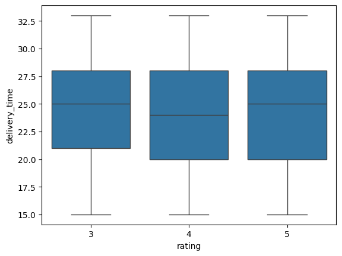

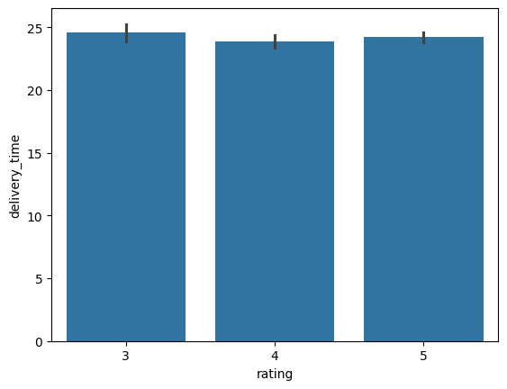

```python
#Delivery time vs rating using the subset of data where non rated orders are removed.
sns.boxplot(data=food_hub_data_rated_only, y="delivery_time", x="rating")
plt.show()

sns.barplot(data=food_hub_data_rated_only, y="delivery_time", x="rating")
plt.show()
```

## Cost of the order vs rating##

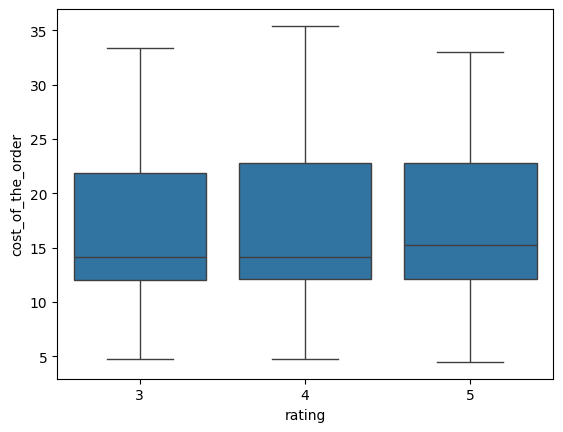

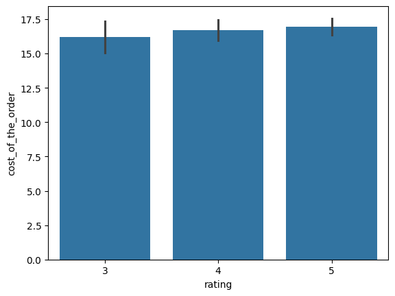

```python
#Cost of the order vs rating using the subset of data where non rated orders are removed.
sns.boxplot(data=food_hub_data_rated_only, y="cost_of_the_order", x="rating")
plt.show()

sns.barplot(data=food_hub_data_rated_only, y="cost_of_the_order", x="rating")
plt.show()
```

- Regardless of the resturant rating, most of the costs remain at 22 dollars or less.
- Restuarants with a rating of 5 have more orders that are 15 dollars and above compared to restaurants with a rating of 3 or 4, which both have most of the orders being priced at 14 dollars or above. So a very minor difference.
- In general the cost of the the order does not really affect the rating.

# Food preparation time vs rating##

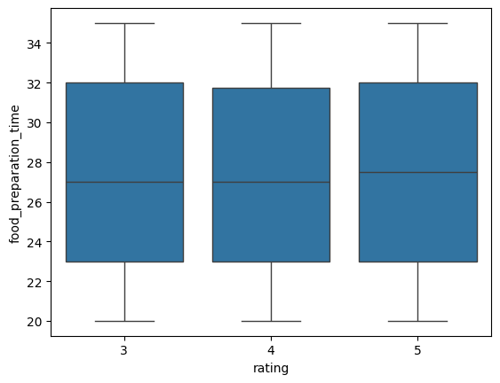

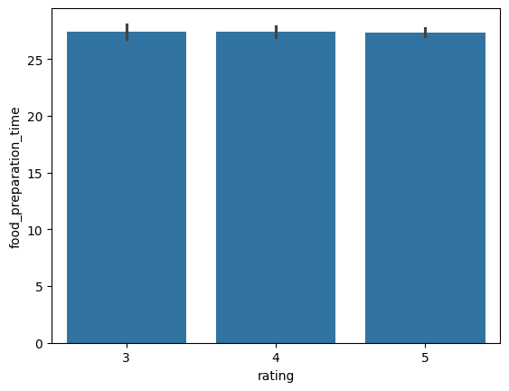

```python
#Food preparation time vs rating using the subset of data where non rated orders are removed.
sns.boxplot(data=food_hub_data_rated_only, y="food_preparation_time", x="rating")
plt.show()

sns.barplot(data=food_hub_data_rated_only, y="food_preparation_time", x="rating")
plt.show()
```

- The food preparation time range between restaurants with a rating of 3 or 5 is within the same range of 24 to 32 minutes. There is a small bump with a restaurant with a rating of 5, but very neglible. This suggessts that food prepartion time does not really impact the rating.

# Cuisine type vs rating##

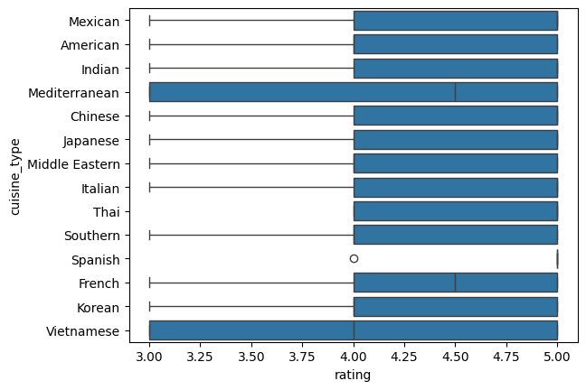

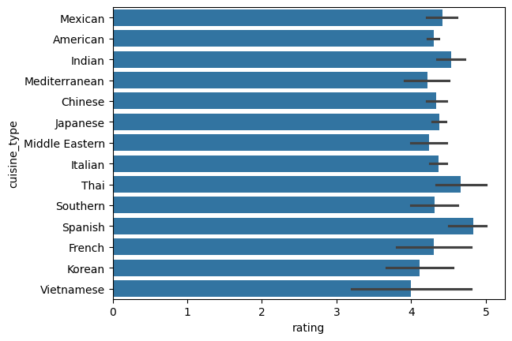

```python
#Cuisine type vs rating using the subset of data where non rated orders are removed.
sns.boxplot(data=food_hub_data_rated_only, y="cuisine_type", x="rating")
plt.show()

sns.barplot(data=food_hub_data_rated_only, y="cuisine_type", x="rating")
plt.show()
```

- 11/14 or roughly 78.5% of the cuisine types have a rating of 4 or higher fairly consistently. This suggests that the most of the ratings are not really influenced by the cuisine type.
- Mediterannean and Vietnamese cusine seem to have the lagest varying of ratings as it goes from 3 to 5 vs 4 and above mentioned in the first bullet point.
- Spanish cuisine has an outlier rating of 4 and then a handful a ratings at 5. So it seems like this style of cuisine has not received many orders compared to other cuisine types. So this may suggest this is one the least popular cuisine types for this dataset.

### Observation delivery time vs cuisine type##

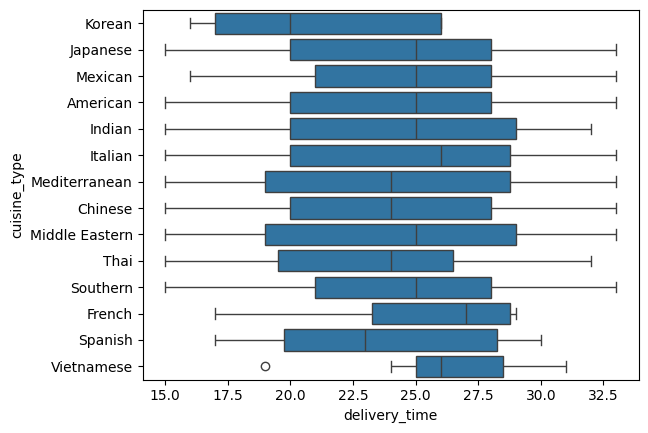

```python
#Delivery time vs cuisine type
sns.boxplot(data=food_hub_data, x="delivery_time", y="cuisine_type")
plt.show()
```

- In general the delivery time is across all cusine types is right around 28 minutes or less. So this tends to suggest that for the most part delivery time isn't significantly affected by the cusiine type.
- Korean has the quickest deliver time coming in at around 25 minutes or less, followed by Thai food at around 26 minutes or less.
- Indian and Middle Eastern food has the longest delivery times at around 28 minutes or less.
- There is one outlier with Vietnamese food where the delivery time is around 18 minutes.

### Observation cost of the order time vs cuisine type##

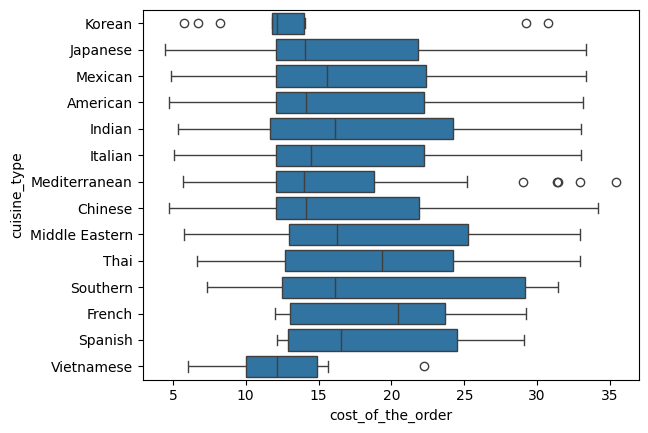

```python
#Cost of the order vs cuisine type
sns.boxplot(data=food_hub_data, x="cost_of_the_order", y="cuisine_type")
plt.show()
```

### Observation food preparation time vs cuisine type##

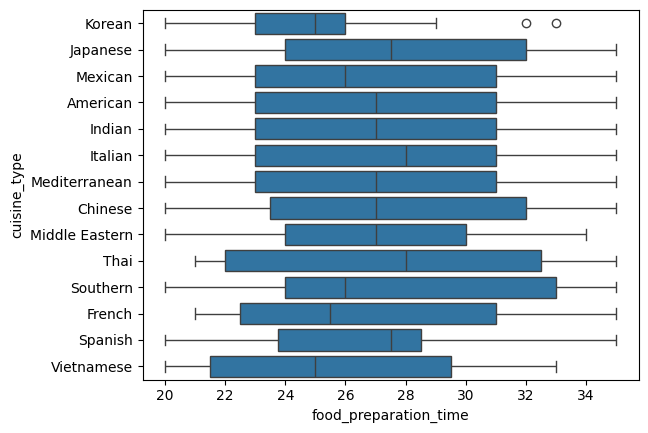

```python
sns.boxplot(data=food_hub_data, x="food_preparation_time", y="cuisine_type")
plt.show()
```

- Most of the cuisine types are prepared in 31 minutes or less.
- In general Korean food tends to have the quickest prepartion time beteen 23 and 25 minutes. There is one outlier in the food prep time here at 32 and 33 minutes.
- Southern food and Thai food take the longest to prepare in 33 and 32 minutes or less respectively.
- In general the cuisine type does not significantly impact the average food prep time.

## Observation delivery time vs day of the week##

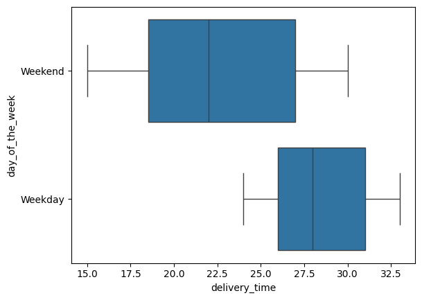

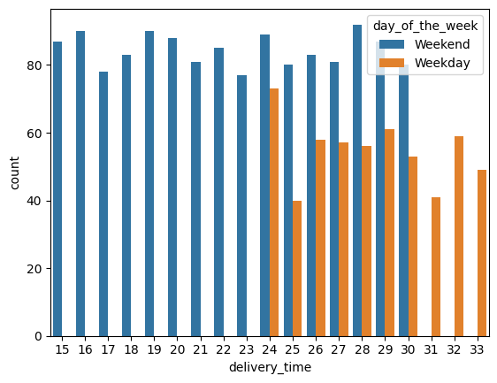

```python
# Delivery time vs day of the week
sns.boxplot(data=food_hub_data, x="delivery_time", y="day_of_the_week")
plt.show()

sns.countplot(data=food_hub_data, x="delivery_time", hue="day_of_the_week")
plt.show()
```

- In general there is higher demand on the weekends based on more delivery time entries being displayed.
- In general on the weekends delivery times are 30 minutes or less.
- In general on the weekdays delivery times are a bit higher at 33 minutes or less.
- There are more orders that happen in 24 minutes or less in general.
- On the weekends it looks like the most orders took 28 minutes to delivery.
- It would be useful if the day of the week could be broken into time stamps or further days (M,T,W,T,F,Sa,Su) so that we could see if there were are any trends on specific days on the weekend or weekdays for the delivery time.
- There are no outliers on the delivery_time for the weekend and weekday.

## Observation cost of the order vs day of the week##

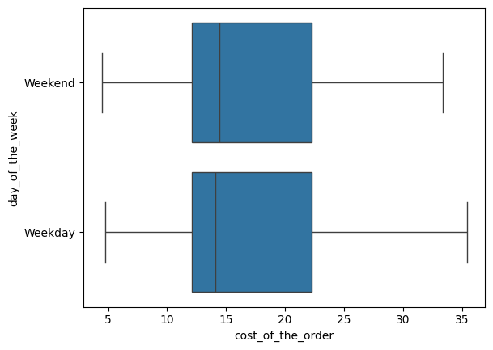

[figure not shown]

```python
sns.boxplot(data=food_hub_data, x="cost_of_the_order", y="day_of_the_week")
plt.show()

sns.countplot(data=food_hub_data, x="cost_of_the_order", hue="day_of_the_week")
plt.show()
```

- There are no outliers on the cost of the order for the weekend or weekday.
- In general the orders are ~22 dollars or less.
- The data is right skewed.
- Even though there is higher demand on the weekends, cost does not generally change between the weekend or weekday. This suggests there there isn't any sort of price surging going on based on demand and that the cost of the food orders are more or less fixed regardless of the day of the week the order is placed.